# WineData

```python
import pandas as pd
```

```python
!pip install pandas
```

```python
import pandas as pd
wine_df = pd.read_csv("datasets/White.csv")
wine_df.head(3)
```

|  | Name | Country | Region | Winery | Rating | NumberOfRatings | Price | Year |
| --- | --- | --- | --- | --- | --- | --- | --- | --- |
| 0 | Vermentino 2017 | Italy | Toscana | Famiglia Castellani | 3.8 | 25 | 5.65 | 2017 |
| 1 | Ronco Broilo 2010 | Italy | Colli Orientali del Friuli | Conte d'Attimis Maniago | 4.3 | 25 | 44.90 | 2010 |
| 2 | Weisser Schiefer s 2017 | Austria | Südburgenland | Weinbau Uwe Schiefer | 4.2 | 25 | 33.25 | 2017 |

DataSet cleaning:

From what I am able to gather the dataset is clean. I will be gather data from the world market of wine. Everything seems to be properly annotated and filled out in regards to the information provided. The features seem to be 'Name', 'Country', 'Region', 'Winery', 'Rating', 'NumberOfRatings', 'Price', 'Year')aset

```python
wine_df.columns
# provides columns
```

```
Index(['Name', 'Country', 'Region', 'Winery', 'Rating', 'NumberOfRatings',
       'Price', 'Year'],
      dtype='object')
```

```python
wine_df.dtypes
# Making sure that data types are what you wnat them to be.
```

```
Name                object
Country             object
Region              object
Winery              object
Rating             float64
NumberOfRatings      int64
Price              float64
Year                object
dtype: object
```

```python
wine_df.index
#index values of our data sets
```

```
RangeIndex(start=0, stop=3764, step=1)
```

```python
import pandas as pd
wine_df = pd.read_csv("datasets/White.csv")
wine_df.head(3)
```

```python
wine_df.shape
# 3,764 roll and we have 8 columns
```

```
(3764, 8)
```

```python
wine_df.describe()
# Basic statiscs that describes the data
```

|  | Rating | NumberOfRatings | Price |
| --- | --- | --- | --- |
| count | 3764.000000 | 3764.000000 | 3764.000000 |
| mean | 3.817906 | 187.567216 | 20.620319 |
| std | 0.266827 | 1071.470441 | 30.928415 |
| min | 2.200000 | 25.000000 | 3.740000 |
| 25% | 3.600000 | 43.000000 | 9.260000 |
| 50% | 3.800000 | 77.000000 | 13.150000 |
| 75% | 4.000000 | 174.250000 | 20.865000 |
| max | 4.900000 | 62980.000000 | 681.370000 |

Features: Name, Country, Region, Winery, Rating, Number of ratings, Price, Year

[figure not shown]

```python
wine_df.tail(3)
```

|  | Name | Country | Region | Winery | Rating | NumberOfRatings | Price | Year |
| --- | --- | --- | --- | --- | --- | --- | --- | --- |
| 3761 | Sauvignon Blanc 2018 | New Zealand | Marlborough | Kim Crawford | 3.9 | 5105 | 14.90 | 2018 |
| 3762 | Sauvignon Blanc 2019 | New Zealand | Marlborough | Hans Greyl | 4.2 | 5817 | 7.75 | 2019 |
| 3763 | Vinho Verde Branco N.V. | Portugal | Vinho Verde | Casal Garcia | 3.7 | 62980 | 4.35 | N.V. |

plt.title('Price Trend Over Time for France', fontsize=16)

plt.xlabel('Year', fontsize=14) plt.ylabel('Price (USD)', fontsize=14)

plt.grid(True) plt.show()

```python
### The difference between .lc and .iloc
```

```python
# Calculating the mean of the rating and price
```

```python
average_rating = wine_df["Rating"].mean()

average_price = wine_df["Price"].mean()

print(f"Average Rating: {average_rating}")
print(f"Average Price: ${average_price:.2f}")
```

```
Average Rating: 3.817906482465462
Average Price: $20.62
```

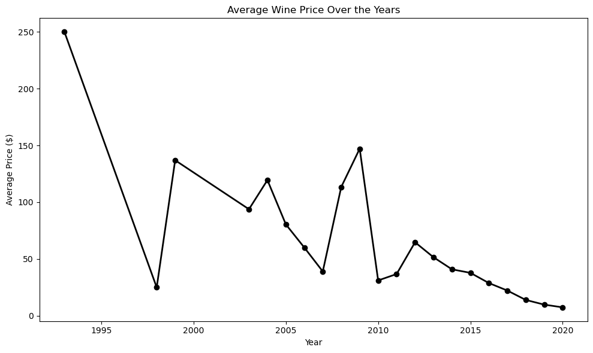

```python
import pandas as pd
import matplotlib.pyplot as plt

wine_df = pd.read_csv('datasets/White.csv')

wine_df['Year'] = pd.to_numeric(wine_df['Year'], errors='coerce')
wine_df['Price'] = pd.to_numeric(wine_df['Price'], errors='coerce')
#similiar concept like in the example
average_price_per_year = wine_df.groupby('Year')['Price'].mean().reset_index()
# thrid time

plt.figure(figsize=(10, 6))
plt.plot(average_price_per_year['Year'], average_price_per_year['Price'], marker='o', color='black', linestyle='-', linewidth=2)
#easy labeling
plt.xlabel('Year')
plt.ylabel('Average Price ($)')
plt.title('Average Wine Price Over the Years')
plt.tight_layout()
plt.show()
```

```python
import os
print(os.path.abspath("datasets/White.csv"))
```

[output not shown]

# plt.ylable

import pandas as pd import matplotlib.pyplot as plt wine_df = pd.read_csv('datasets/White.csv')

https://mode.com/blog/python-data-visualization-libraries#matplotlib

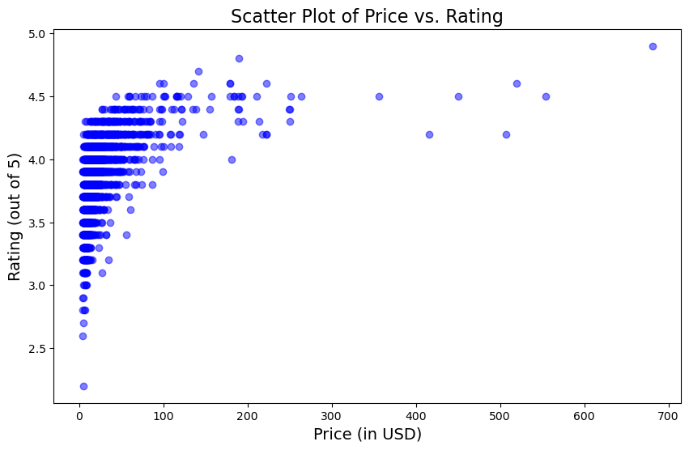

```python
import pandas as pd
import matplotlib.pyplot as plt
wine_df = pd.read_csv('datasets/White.csv')

plt.figure(figsize=(10, 6))
plt.scatter(wine_df['Price'], wine_df['Rating'], alpha=0.5, color='blue')

plt.title('Scatter Plot of Price vs. Rating', fontsize=16)
plt.xlabel('Price (in USD)', fontsize=14)
plt.ylabel('Rating (out of 5)', fontsize=14)

plt.show()
```

```
                            shows the average price and average rating of wines from each country
```

import pandas as pd import matplotlib.pyplot as plt wine_df = pd.read_csv('datasets/White.csv')

https://dataplotplus.com/how-to-create-bar-plot-with-two-y-axis-bars-in-pandas/ https://cmdlinetips.com/2019/10/how-to-make-a-plot-with-two-different-y-axis-in-python-with-matplotlib/#google_vignette https://www.statology.org/matplotlib-two-y-axes/

country_avg = wine_df.groupby('Country').agg({'Price': 'mean', 'Rating': 'mean'}).reset_index()

fig, ax1 = plt.subplots(figsize=(12, 6)) ax1.bar(country_avg['Country'], country_avg['Price'], color='lightblue', alpha=0.7, label='Average Price ($$$)') ax1.set_xlabel('Country', fontsize=14) ax1.set_ylabel('Average Price ($$$)', fontsize=14, color='blue') ax1.set_title('Country Based Analysis: Average Price & Rating', fontsize=16)

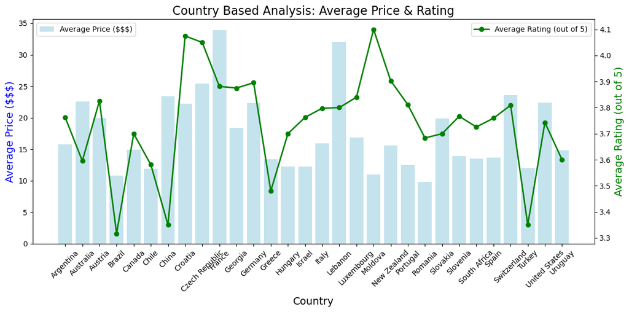

```python
import pandas as pd
import matplotlib.pyplot as plt
wine_df = pd.read_csv('datasets/White.csv')

country_avg = wine_df.groupby('Country').agg({'Price': 'mean', 'Rating': 'mean'}).reset_index()
fig, ax1 = plt.subplots(figsize=(12, 6))
ax1.bar(country_avg['Country'], country_avg['Price'], color='lightblue', alpha=0.7, label='Average Price ($$$)')
ax1.set_xlabel('Country', fontsize=14)
ax1.set_ylabel('Average Price ($$$)', fontsize=14, color='blue')
ax1.set_title('Country Based Analysis: Average Price & Rating', fontsize=16)


ax2 = ax1.twinx()
ax2.plot(country_avg['Country'], country_avg['Rating'], color='green', marker='o', label='Average Rating (out of 5)', linewidth=2)
ax2.set_ylabel('Average Rating (out of 5)', fontsize=14, color='green')

ax1.tick_params(axis='x', rotation=45)
ax1.legend(loc='upper left')
ax2.legend(loc='upper right')

plt.tight_layout()
plt.show()
```